# The Bootstrap

## What it is

## Hall, P. The Bootstrap and Edgeworth Expansion

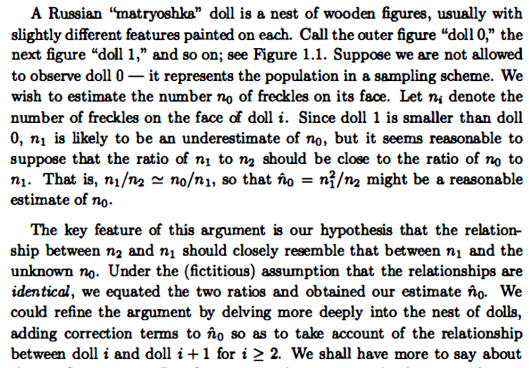

(DO NOT START WITH THIS TEXT!)

## A (somewhat) rigorous definition

- \(X_1,\cdots,X_n\sim F\)
- \(\theta\) is parameter of \(F\)
- \(\hat{\theta}_n\) is an estimator of \(\theta\), \(\hat{\theta}_n=t_n(X_1\cdots X_n)\)
- \(\theta\) is Level 1 parameter, parameters of \(\hat{\theta}_n\) are Level 2 parameters, e.g. \(Var(\hat{\theta}_n)\)
- The bootstrap estimates Level 2 parameters
- \(X \sim N(\mu,\sigma)\), \(\mu\) is a level 1 parameter
- \(\mbox{bias}(\hat{\mu})=X_{(n/2)}-\mu\), is a level 2 parameter
- Bootstrap can estimate properties of \(\hat{\mu}\), cannot estimate properties of \(\mu\)

## How it works

- Observe \(X_1,\cdots,X_n\) from \(F\), say \(F \sim Exp(\theta)\)
- Calculate \(\hat{\theta}_n\) from original data
- Construct an estimate of \(F\) from data, \(\tilde{F}_n\)
- Generate IID samples from \(\tilde{F}_n\), commonly \(X_1^*, \cdots X_n^*\)
- Calculate \(\theta_n^*\) from bootstrap sample
- If \(\tilde{F}_n\) is chosen appropriately then the relationship between \(\hat{\theta}_n\) and \(\theta\) is accurately mimicked by examining the relationshp between \(\theta_n^*\) and \(\hat{\theta}\)

## Choices for \(\tilde{F}_n\)

- \(\tilde{F}_n(.) \equiv n^{-1} \sum_{i=1}^n \mathbb{I}(X_i \leq .)\) i.e. EDF

```r
x<-rexp(10,4)
theta<-mean(x)
x.star<-sample(x,10,replace=T)
```

- \(\tilde{F}_n(.) \equiv F(\hat{\theta})\)

```r
x<-rexp(10,4)
theta.hat<-1/mean(x)
x.star<-rexp(10,theta.hat)
```

## Mimic relationship between \(\theta\) and \(\hat{\theta}\)

- Say want to estimate \(E[\hat{\theta}_n-\theta]\) (Property of \(\hat{\theta}\))
- Build empirical estimate of \(\theta_n^* - \hat{\theta}_n\)

```r
M<-5000
emp.bias<-c()
theta<-4
for(i in 1:M){
  x<-rexp(10,theta)
  theta.hat<-1/mean(x) #MLE for Theta
  x.star<-sample(x,10,replace=T)
  theta.star<-1/mean(x.star)
  emp.bias[i]<-theta.star-theta.hat
}
mean(emp.bias)
```

```
## [1] 0.4275414
```

## Aside

- \(X_i \sim Exp(\theta)\) implies \(\sum_{i=1}^n X_i \sim Gam(n,\theta)\)
- \(Y \equiv \frac{1}{\sum_{i=1}^n X_i} \sim IG (n,\theta)\)
- \(E[Y] = \frac{\theta}{n-1}\), so \(E\left[\frac{10}{\sum_{i=1}^{10} X_i}\right]=\frac{10}{9} \theta\)
- So Bias should be \(\frac{4}{9}=.444\) (Certainly not trivial for 206 students)

## Probability Bias is less than .75

```r
M<-5000
emp.bias<-c()
for(i in 1:M){
  x<-rexp(10,4)
  theta.hat<-1/mean(x)
  x.star<-sample(x,10,replace=T)
  theta.star<-1/mean(x.star)
  emp.bias[i]<-theta.star-theta.hat
}

length(emp.bias[abs(emp.bias)]<.75)/M
```

```
## [1] 0.3722
```

## Could also do

Parametric bootstrap, \(\tilde{F}_n(.) \equiv F(\hat{\theta})\)

```r
M<-5000
emp.bias2<-c()
for(i in 1:M){
  x<-rexp(10,theta)
  theta.hat<-1/mean(x)
  x.star<-rexp(x,theta.hat)
  theta.star2<-1/mean(x.star)
  emp.bias2[i]<-theta.star2-theta.hat
}
mean(emp.bias2)
```

```
## [1] 0.527021
```

Makes distributional assumptions

## Why does this work?

- Let \(T_n\) be normalized sample mean, \(T_n \equiv n^{1/2}\left(\bar{X}-\mu\right)/ \sigma\) and \(\tilde{F}_n\) be empirical distribution
- \(T^*_n = n^{1/2}\left(\bar{X}^*_n - E_* X^* \right)/Var_* (X^*)^{1/2}\)
- As we are using empirical distribution \(E_* (X^*)^k = n^{-1}\sum_{i=1}^n X_i^k\)
- Thus, \(T^*_n =n^{1/2} \left(\bar{X}^*_n -\bar{X}_n\right)/s_n\)

## Berry-Esseen Theorem

- Let \(X_1,\cdots,X_n\) be a collection of independent random variables with \(E X_j =0\) and \(E|X_j|^3 < \infty\). If \(\sigma_n^2 >0\), then \[ \sup_{x \in \mathbb{R}} | P(\frac{1}{\sqrt{n}\sigma_n}\sum_{j=1}^n X_j \leq x) - \Phi (x)|\\ \leq 2.75 \frac{1}{n^{3/2}}\sum_{j=1}^n E|X_j|^3/\sigma_n^3 \]
- A mouthful but a remarkable result

## How this relates to bootstrap

Recall \(T^*_n =n^{1/2} \left(\bar{X}^*_n -\bar{X}_n\right)/s_n\) is bootstrap statistic

Berry-Essen Gives \[ \sup_{x \in \mathbb{R}} | P(T^*_n\leq x) - \Phi (x)|\\ \leq 2.75 \frac{1}{s_n^3 \sqrt{n}} E_* |X_1^* - \bar{X}_n|^3 \\ = 2.75 \frac{1}{s_n^3 n^{3/2}}\sum_{i=1}^n |X_i-\bar{X}_n|^3 \]

By a version of SLLN \(\frac{1}{n^{3/2}}\sum_{i=1}^n |X_i-\bar{X}_n|^3 \to 0\) meaning \(\sup_{x \in \mathbb{R}} | P(T^*_n\leq x) - \Phi (x)| \to 0\)

## Cont.

- Intuitively, \(X \sim F\) with \(E|X|^2 < \infty\) we have CLT, EDF is a distribution, hence EDF has CLT
- \(T^*_n \to N(0,1)\), \(T_n \to N(0,1)\), therefore, \(T^*_n \to T_n\)
- Can be shown to converge at \(o(n^{-1/2})\) whereas the classical normal approximation converges at \(O(n^{-1/2})\)

## Bootstrap Confidence Intervals

- Key point of bootstrap, you have to bootstrap something with a limiting distribution, e.g. \(n^{1/2}(\hat{\theta}-\theta) \to N(0,\sigma^2_{\theta})\)

```r
x<-rnorm(3000);mu.hat<-mean(x);bs.star<-c()
for(l in 1:3000){
  x.star<-sample(x,length(x),replace=T)
  mu.star<-mean(x.star)
  bs.star[l]<-(mu.star-mu.hat)*sqrt(length(x))}
mean(bs.star)
```

```
## [1] 0.001463846
```

```r
var(bs.star)
```

```
## [1] 0.9697263
```

## Bootstrap Confidence Intervals

- However, if \(E[X^2]=\infty\), then makes no sense to bootstrap \(n^{1/2}(\hat{\theta}-\theta)\)

```r
x<-rcauchy(3000);mu.hat<-mean(x);bs.star<-c()
for(l in 1:3000){
  x.star<-sample(x,length(x),replace=T)
  mu.star<-mean(x.star)
  bs.star[l]<-(mu.star-mu.hat)*sqrt(length(x))
}
mean(bs.star)
```

```
## [1] 0.034672
```

```r
var(bs.star)
```

```
## [1] 836.026
```

## Bootstrap Confidence Intervals

- Bootstrapping something of the form \(n^{1/2}(\hat{\theta}_n-\theta)\)
- \(Pr(\theta < L_{\alpha}) = \alpha/2\) and \(P(\theta < U_\alpha)=1-\alpha/2\)
- \[ Pr(n^{1/2}(\hat{\theta}_n-\theta) > n^{1/2}(\hat{\theta}_n-L_{\alpha}))=\alpha/2\]
- \(n^{1/2}(\hat{\theta}_n-L_{\alpha}))\) is the \(1-\alpha/2\) quantile of \(n^{1/2}(\hat{\theta}_n-\theta)\)
- \[L_{\alpha} \approx \hat{\theta}_n-(\theta^*-\hat{\theta}_n)_{[(M+1)(1-\alpha/2)]}\\ =2 \hat{\theta}_n - \theta^*_{[(M+1)(1-\alpha/2)]}\]
- Similarly \(U_{\alpha} \approx 2\hat{\theta}_n - \theta^*_{[(M+1)(\alpha/2)]}\)

## Percentile Bootstrap Interval

- Regardless of comparison function (as long as it has limiting distribution) may be able to use \[\left(\theta^*_{[(M+1)(\alpha/2)]},\theta^*_{[(M+1)(1-\alpha/2)]}\right)\]
- In practice does it matter?

## Neither Sometimes Work Well…

```r
perc.count<-0;basic.count<-0;true.mean<-.5
for(k in 1:200){
  x<-rgamma(10,2,4)
  theta.star<-c()
  for(l in 1:3000){
    x.star<-sample(x,length(x),replace=TRUE)
    theta.star[l]<-mean(x.star)
  }
  perc.lb<-sort(theta.star)[.025*length(theta.star)]
  perc.ub<-sort(theta.star)[.975*length(theta.star)]
  basic.lb<-2*mean(x)-perc.ub
  basic.ub<-2*mean(x)-perc.lb
  if(perc.lb<true.mean&perc.ub>true.mean){perc.count<-perc.count+1}
  if(basic.lb<true.mean&basic.ub>true.mean){basic.count<-basic.count+1}
}
print(c(perc.count/200, basic.count/200))
```

```
## [1] 0.855 0.855
```

## That Pesky Third Moment

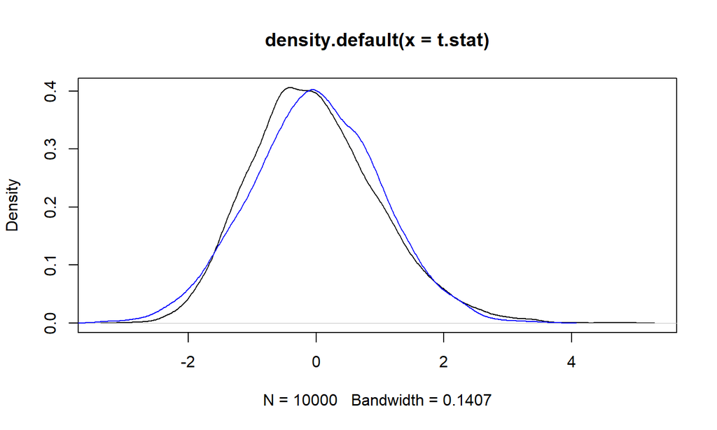

Issue in tails.

## Some other bootstrap confidence intervals

- Bootstrap t interval, \(\hat{\theta}\pm t_{\alpha/2,n-1}\mbox{SE}_b\) (Not any better than using t-distribution)
- Expanded percentile interval: if normal than \(F^{*-1}(\alpha/2)\approx \hat{\theta}+z_{\alpha/2}\hat{\sigma}/\sqrt{n}\)
- Want to use quantiles that correspond to \(t_{\alpha/2} s/ \sqrt{n}\)

\[F^{*-1}(\alpha'/2) \approx \hat{\theta}+z_{\alpha'/2}\hat{\sigma}/\sqrt{n} \\ \approx \hat{\theta}+t_{\alpha/2}s/\sqrt{n}\]

- So \(z_{\alpha'/2} = \sqrt{n/(n-1)}t_{\alpha/2}\) which implies \(\alpha'/2 = \phi(\sqrt{n/(n-1)}t_{\alpha/2})\)

## Expanded percentile interval in practice

```r
adj.count<-0;true.mean<-.5;perc.count<-0
for(k in 1:200){
  x<-rgamma(10,2,4);theta.star<-c(); n<-length(x)
  for(l in 1:3000){
    x.star<-sample(x,length(x),replace=TRUE);theta.star[l]<-mean(x.star)
  }
  quant<-pnorm(sqrt(n/(n-1))*qt(.025,n-1))
  exp.lb<-sort(theta.star)[quant*length(theta.star)]
  exp.ub<-sort(theta.star)[(1-quant)*length(theta.star)];length<-exp.ub-exp.lb
  if(exp.lb<true.mean&exp.ub>true.mean){perc.count<-perc.count+1}
}
print(c(perc.count/200))
```

```
## [1] 0.92
```

## Bootstrap t-distribution

- Use Empirical distribution of \(\frac{\hat{\theta}^*-\hat{\theta}}{\hat{S}^*}\) to estimate the distribution of \(\frac{\hat{\theta}-\theta}{\hat{S}}\)
- Preserves skewness of \(t\) statistic
- Pedagogical tool as builds up distribution of \(t\) statistic as opposed to assuming it is known

## Bootstrap t-distribution

```r
t.stat<-0;true.mean<-.5;t.count<-0
for(k in 1:200){
  x<-rgamma(10,2,4);theta.star<-c()
  for(l in 1:3000){
    x.star<-sample(x,length(x),replace=TRUE);
    theta.star[l]<-mean(x.star)
    t.stat[l]<-(theta.star[l]-mean(x))/(sd(x.star)/sqrt(10)*sqrt(9/10))
  }
  t.lb<-sort(t.stat)[.025*length(t.stat)]
  t.ub<-sort(t.stat)[.975*length(t.stat)]
  lb<-mean(x)-t.ub*sd(x)/sqrt(length(x))
  ub<-mean(x)-t.lb*sd(x)/sqrt(length(x))
  if(lb<true.mean&ub>true.mean){t.count<-t.count+1}
}
print(c(t.count/200))
```

```
## [1] 0.945
```

## Bias Corrected Accelerated Bootstrap

- Percentile CI might be biased, so first compute bias correction factor \(\hat{z}_0 = \Phi^{-1}(\mathbb{I}\left(\hat{\theta^*}<\hat{\theta}\right)/B)\)
- Can think of this as the median bias of \(\hat{\theta^*}\)
- Biasness also manifests in higher order Edgeworth terms

## Acceleration computation

\[P(t \leq x) = \Phi (x) + \sum_{i=1}^k n^{-i/2}P_i(x) \phi(x) + o(n^{-k/2})\]

- So can explicitely correct for higher order terms
- Next term in particular is \(P_1(x) = \frac{1}{6} E(X-\mu)^3 Var(X)^{-3/2} (2x^2+1)\)
- Estimate 'acceleration' by estimating \(A=\frac{1}{6} E(X-\mu)^3 Var(X)^{-3/2}\)
- Jacknife estimate traditionally employed to find \(\hat{A}\)

## BCa

```r
library(resample)
t.stat<-0;true.mean<-.5;t.count<-0
for(k in 1:200){
  x<-rgamma(10,2,4);theta.star<-c()
  bs.samp<-resample::bootstrap(x,mean,R=2000)
  bca.ci<-CI.bca(bs.samp)
  bca.lb<-bca.ci[1]
  bca.ub<-bca.ci[2]
  if(bca.lb<true.mean&bca.ub>true.mean){t.count<-t.count+1}
}
print(c(t.count/200))
```

```
## [1] 0.94
```

## What the bootstrap isn't

## Is not a panacea for small data

```r
perc.count<-0;basic.count<-0;true.mean<-.5
for(k in 1:500){
  x<-rgamma(100,2,4)
  theta.star<-c()
  for(l in 1:3000){
    x.star<-sample(x,length(x),replace=TRUE)
    theta.star[l]<-mean(x.star)
  }
  perc.lb<-sort(theta.star)[.025*length(theta.star)]
  perc.ub<-sort(theta.star)[.975*length(theta.star)]
  basic.lb<-2*mean(x)-perc.ub
  basic.ub<-2*mean(x)-perc.lb
  if(perc.lb<true.mean&perc.ub>true.mean){perc.count<-perc.count+1}
  if(basic.lb<true.mean&basic.ub>true.mean){basic.count<-basic.count+1}
}
print(c(perc.count/500, basic.count/500))
```

```
## [1] 0.954 0.950
```

## Is not a panacea for small data

- Proof that it works relies on \(n \to \infty\)
- Confusion in different \(n\) terms
- Original, observed data, \(X_1,\cdots, X_n\) - This is set by nature or data limitations
- Bootstrap sample is of same size as data, \(X^*_1,\cdots, X^*_n\), again, not chosen by user
- Number of bootstrap samples, \(\theta^*_1,\cdots,\theta^*_m\) is chosen by user, is irrelevant for proof of whether bootstrap works or not
- The larger \(m\) is, the closer the empirical distribution of, say, \(n^{1/2}(\theta^*-\hat{\theta})\) is to the true distribution of \(n^{1/2}(\theta^*-\hat{\theta})\)

## Bootstrap is not an excuse to not learn theory

- Need to know there is a limiting distribution for \(n^{1/2}(\hat{\theta}-\theta)\), if there isn't, makes no sense to bootstrap it
- Fortunately have MLE theory, so in broad setting we are good \(n^{1/2}(\hat{\theta}_{mle}-\theta) \to N(0,\sigma_{\hat{\theta}})\)
- Biased corrected accelerated relies on Edgeworth expansion theory

## The bootstrap tells us nothing new about the population parameter, \(\theta\)

- The bootstrap gives no new information about \(\theta\), it only tells us things about the distribution of functionals of \(\hat{\theta}\)
- It may indirectly tell us something about \(\theta\), say by forming confidence intervals for \(\theta\), however if our method for estimating \(\hat{\theta}\) is bad, then we are not saved.

```r
data<-rnorm(100);mu.hat<-sort(data)[length(data)*.60]
for(l in 1:5000){
  dat.star<-sample(data,length(data),replace=TRUE)
  mu.star[l]<-sort(dat.star)[length(dat.star)*.60]}
c(sort(mu.star)[.025*length(mu.star)],sort(mu.star)[.975*length(mu.star)])
```

```
## [1] 0.08097939 0.41041457
```

## What can go horribly, horribly wrong

## Consider the following

- \(Y_t = 3+ \epsilon_t+.5\epsilon_{t-1}\) and \(\epsilon_t \sim N(0,1)\)
- Can be shown \(Var(\sqrt{n}\bar{Y}_n)=\sum_{k=-n}^n \left(1-\frac{|k|}{n}\right)r(k)\) where \(r(k)=Cov(Y_t,Y_{t+k})\)
- In this case \(Cov(Y_t,Y_t)= 1.25\), \(Cov(Y_t,Y_{t-1})= .5\), \(Cov(Y_t,Y_{t+1})= .5\), so for, say, \(n=10\), \(Var(\sqrt{n}\bar{Y}_n)=2.15\)

## Cont.

```r
epsilons<-rnorm(10)
y.t<-c()
y.t[1]=3+epsilons[1]
for(j in 2:10){
  y.t[j]=3+epsilons[j]+.5*epsilons[j-1]
}
theta.star<-c()
for(k in 1:5000){
  y.star<-sample(y.t,length(y.t),replace=TRUE)
  n<-length(y.star)
  theta.star[k]<-sqrt(n)*(mean(y.star)-mean(y.t))
}
var(theta.star)
```

```
## [1] 0.9618082
```

## Maybe \(n\) isn't big enough?

- In this case \(Cov(Y_t,Y_t)= 1.25\), \(Cov(Y_t,Y_{t-1})= .5\), \(Cov(Y_t,Y_{t+1})= .5\), so for, say, \(n=100\), \(Var(\sqrt{n}\bar{Y}_n)=2.24\)

```r
epsilons<-rnorm(100);y.t<-c()
y.t[1]=3+epsilons[1]
for(j in 2:100){
  y.t[j]=3+epsilons[j]+.5*epsilons[j-1]
}
theta.star<-c()
for(k in 1:5000){
  y.star<-sample(y.t,length(y.t),replace=TRUE);n<-length(y.star)
  theta.star[k]<-sqrt(n)*(mean(y.star)-mean(y.t))
}
var(theta.star)
```

```
## [1] 1.000061
```

## Even Worse

- \(Y_t = 3+.5 Y_{t-1}+\epsilon_t\), \(\epsilon \sim N(0,1)\)
- \(Cov(Y_t,Y_{t \pm k})=\frac{1}{1-.5^2} .5^k\)
- So, if \(n=10\) we have \(Var(n^{1/2}\bar{X})=3.47\)

## In case you don't believe me…

```r
y.bar<-c()
for(k in 1:1000){
  epsilons<-rnorm(100)
  y.t<-c()
  y.t[1]<-3+epsilons[1]
  for(j in 2:100){
    y.t[j]<-3+.5*y.t[j-1]+epsilons[j]
  }
  y.bar[k]<-mean(y.t[81:90])
}
var(sqrt(10)*y.bar)
```

```
## [1] 3.353847
```

## Let's Bootstrap

```r
y.t.partial<-y.t[81:90];theta.star<-c()
for(k in 1:5000){
  y.star<-sample(y.t.partial,length(y.t.partial),replace=TRUE)
  n<-length(y.star)
  theta.star[k]<-sqrt(n)*(mean(y.star)-mean(y.t.partial))
}
var(theta.star)
```

```
## [1] 1.396785
```

- The worst sin a statistician can commit…

## Not saved by asymptotics, \(n=90\)

```r
y.bar<-c();theta.star<-c()
for(k in 1:1000){
  epsilons<-rnorm(100)
  y.t<-c()
  y.t[1]<-3+epsilons[1]
  for(j in 2:100){
    y.t[j]<-3+.5*y.t[j-1]+epsilons[j]
  }
  y.bar[k]<-mean(y.t[11:100])
}
var(sqrt(90)*y.bar)
```

```
## [1] 4.068871
```

## Not saved by asymptotics

```r
y.t.partial<-y.t[11:100];theta.star<-c()
for(k in 1:5000){
  y.star<-sample(y.t.partial,length(y.t.partial),replace=TRUE)
  n<-length(y.star)
  theta.star[k]<-sqrt(n)*(mean(y.star)-mean(y.t.partial))
}
var(theta.star)
```

```
## [1] 1.125001
```

## IID Innovation Bootstrap

- \(Y_t = h(Y_{t-1},\cdots,Y_{t-p};\beta)+\epsilon_t\) with \(\epsilon_t \sim \mbox{ iid }F\), \(t>p\)
- Get residuals, \(\hat{\epsilon}_t=Y_t-h(Y_{t-1},\cdots,Y_{t-p};\hat{\beta})\) for \(t=p+1,\cdots,n\)
- Center residuals and put in collection \(C={\epsilon_t-\bar{\hat{\epsilon}}:t=p+1,\cdots,n}\)
- Draw \(\epsilon_t^*,t=p+1,\cdots,n\) by sampling with replacement from \(C\)
- Bootstrap time series is \(X_t^* = h(X_{t-1}^*,\cdots,X_{t-p}^*;\hat{\beta})+\epsilon_t^*\), for \(t=p+1,\cdots,n\)

## IID Innovation Bootstrap

```r
y.t.partial<-y.t[11:100]
y.t.last<-y.t[10:99]
ls.mod<-lm(y.t.partial~y.t.last);coefs<-ls.mod$coefficients
resids<-y.t.partial[-1]-(coefs[1]+coefs[2]*y.t.partial[-length(y.t.partial)])
cent.resids<-resids-mean(resids);theta.star<-c()
for(k in 1:5000){
  eps.star<-sample(cent.resids,length(cent.resids),replace=TRUE)
  y.star<-c();y.star[1]=y.t.partial[1]
  for(l in 2:90){
    y.star[l]<-coefs[1]+coefs[2]*y.star[l-1]+eps.star[l-1]
  }
  n<-length(y.star)
  theta.star[k]<-sqrt(n)*(mean(y.star)-mean(y.t.partial))
}
var(theta.star)
```

```
## [1] 2.980671
```

## Block Bootstrap

- MBB: Let \(B_i=(X_i,\cdots,X_{i+l-1})\) be block of length \(l\) starting with \(X_i\)
- Resample blocks with replacement from collection of \(\{B_1,\cdots,B_M\}\)
- Concate into a single vector, use this as the bootstrap sample
- Also Non-Overlapping block bootstrap, Circular block bootstrap, Sieve bootstrap
- How do you pick block size?

## Block Bootstrap

```r
n<-length(y.t.partial);block.t<-c();block.mat<-matrix(0,nrow=30,ncol=3)
for(j in 1:nrow(block.mat)){
  block.mat[j,]<-y.t.partial[(0+j):(2+j)]
}
block.t<-c()
M<-2000
for(k in 1:M){
  indexes<-sample(nrow(block.mat),nrow(block.mat),replace=T)
  block.boot<-block.mat[indexes,]
  block.t[k]<-sqrt(n)*(mean(block.boot)-mean(y.t.partial))
}
var(block.t)
```

```
## [1] 2.990414
```

## Key Points

- Bootstrap allows us to estimate Level 2 parameters, properties of, say, \(n^{1/2}(\hat{\theta}-\theta)\)
- Does not allow us to better estimate \(\theta\) or tell us how to estimate \(\theta\)
- Percentile bootstrap, though easiest to explain to students, is not the only method (nor is in the best) and it rarely beats the normal approximation (though theoretically it's better)
- Your bootstrap sample must be the same size as your original data
- The bootstrap is centered at the observed estimate, not at the population estimate, \(n^{1/2}(\theta^*-\hat{\theta})\) NOT \(n^{1/2}(\theta^*-\theta)\)

## Resources

- What Teachers Should Know about the Bootstrap: Resampling in the Undergraduate Statistics Curriculum, Hesterberg
- Resampling Methods for Dependent Data, Lahiri
- The Bootstrap and Edgeworth Expansion, Hall